# STAT-427/627 Homework #3

Name:___________________________Course__________

# Admin

Scope:

- Classification: main concepts (4.1-4.2),
- K-nearest neighbor method (2.2.3 and 3.5) and its implementation in R (4.7.6).

30 Points

| Question | 427 | 627 |
| --- | --- | --- |
| 1 | 4 | 4 |
| 2 | 8 | 8 |
| 3 | 16 | 12 |
| 4 |  | 4 |
| 5 | 2 | 2. |
| Total | 30 | 30 |

# 1 Finding Gold!

Big Jim, from Charlie Chaplin’s *Gold Rush*, found a gold mine, and he tries to predict whether or not there is gold at his chosen spot, 150m from his tent (T).

According to past probes, there is gold (G) at the distances of 40, 80, 140, 270, 320, and 340 meters from the tent, but no gold (N) at 100, 120, and 220 meters.

| 0 | 40 | 80 | 100 | 120 | 140 | **150** | 220 | 270 | 320 | 340 |
| --- | --- | --- | --- | --- | --- | --- | --- | --- | --- | --- |
| T | G | G | N | N | G | **?** | N | G | G | G |

1. Use the KNN method with K = 3 to make a prediction at Jim’s chosen spot. Do this manually (no code) and show your work.
2. Use the KNN method with K = 5 to make a prediction at Jim’s chosen spot. Do this manually (no code) and show your work.

|  | 0 | 40 | 80 | 100 | 120 | 140 | **150** | 220 | 270 | 320 | 340 | $\hat{Y}$ |
| --- | --- | --- | --- | --- | --- | --- | --- | --- | --- | --- | --- | --- |
|  | T | G | G | N | N | G | **?** | N | G | G | G |  |
| k = 3 |  |  |  | N | N | G |  |  |  |  |  | N |
| k = 5 |  |  | G | N | N | G |  | N |  |  |  | N |

# 2 KNN Prediction

Page 54, chap. 2, #7.

The table below provides a training data set containing six observations, three predictors, and one qualitative response variable.

| Obs. | $X_1$ | $X_2$ | $X_3$ | $Y$ |
| --- | --- | --- | --- | --- |
| 1 | 0 | 3 | 0 | Red |
| 2 | 2 | 0 | 0 | Red |
| 3 | 0 | 1 | 3 | Red |
| 4 | 0 | 1 | 2 | Green |
| 5 | −1 | 0 | 1 | Green |
| 6 | 1 | 1 | 1 | Red |

Suppose we wish to use this data set to make a prediction for $Y$ when $X_1 = X_2 = X_3 = 1$ using K-nearest neighbors. Do this manually (no code) and show your work.

1. Compute the Euclidean distance between each observation and the test point, $X_1 = X_2 = X_3 = 1$.
2. What is our prediction with $k = 1$? Why?
3. What is our prediction with $k = 3$? Why?
4. If the decision boundary in this problem is highly nonlinear, would we expect the best value for $k$ to be large or small? Why?

*In classification problems, decision boundaries separate different response categories in the* $X$ space of independent variables.

| Obs. | $X_1$ | $X_2$ | $X_3$ | $Y$ | Distance to X=(1,1,1) | Neighbor for $k=1$ | Neighbor for $k = 3$ |
| --- | --- | --- | --- | --- | --- | --- | --- |
| 1 | 0 | 3 | 0 | Red | $2.45 = \sqrt{6}$ |  |  |
| 2 | 2 | 0 | 0 | Red | $1.73 = \sqrt{3}$ |  | Neighbor-R |
| 3 | 0 | 1 | 3 | Red | $2.24 = \sqrt{5}$ |  |  |
| 4 | 0 | 1 | 2 | Green | $1.4 = \sqrt{2}$ |  | Neighbor-G |
| 5 | −1 | 0 | 1 | Green | $2.24 =\sqrt{5}$ |  |  |
| 6 | 1 | 1 | 1 | Red | $0= \sqrt{3}$ | Neighbor-R | Neighbor-R |
| $\hat{Y}$ |  |  |  |  |  | Red | Red |

(d) To capture a highly nonlinear boundary requires a flexible approach, so use small $k$. A small $k$ will produce classification that is more dependent on a small neighborhood, reflecting the local features of a curve.

# 3 Stock Market Prediction

Page 193, chap. 4, #13 (selected questions).

We want to predict the behavior of the stock market in the following week. The `Weekly` data set, (from the {ISLR2} package), contains 1,089 observations with the following 9 variables.

- `Year`: The year that the observation was recorded
- `Lag1`: Percentage return for previous week
- `Lag2`: Percentage return for 2 weeks previous
- `Lag3`: Percentage return for 3 weeks previous
- `Lag4`: Percentage return for 4 weeks previous
- `Lag5`: Percentage return for 5 weeks previous
- `Volume`: Volume of shares traded (average number of daily shares traded in billions)
- `Today`: Percentage return for this week
- `Direction`: A factor with levels `Down` and `Up` indicating whether the market had a positive or negative return on a given week
1. Produce some numerical and graphical summaries of the Weekly data. Do there appear to be any patterns?

```r
suppressMessages(library(tidyverse))
library(ISLR2)
data(Weekly)
glimpse(Weekly)
```

```
Rows: 1,089
Columns: 9
$ Year      <dbl> 1990, 1990, 1990, 1990, 1990, 1990, 1990, 1990, 1990, 1990, …
$ Lag1      <dbl> 0.816, -0.270, -2.576, 3.514, 0.712, 1.178, -1.372, 0.807, 0…
$ Lag2      <dbl> 1.572, 0.816, -0.270, -2.576, 3.514, 0.712, 1.178, -1.372, 0…
$ Lag3      <dbl> -3.936, 1.572, 0.816, -0.270, -2.576, 3.514, 0.712, 1.178, -…
$ Lag4      <dbl> -0.229, -3.936, 1.572, 0.816, -0.270, -2.576, 3.514, 0.712, …
$ Lag5      <dbl> -3.484, -0.229, -3.936, 1.572, 0.816, -0.270, -2.576, 3.514,…
$ Volume    <dbl> 0.1549760, 0.1485740, 0.1598375, 0.1616300, 0.1537280, 0.154…
$ Today     <dbl> -0.270, -2.576, 3.514, 0.712, 1.178, -1.372, 0.807, 0.041, 1…
$ Direction <fct> Down, Down, Up, Up, Up, Down, Up, Up, Up, Down, Down, Up, Up…
```

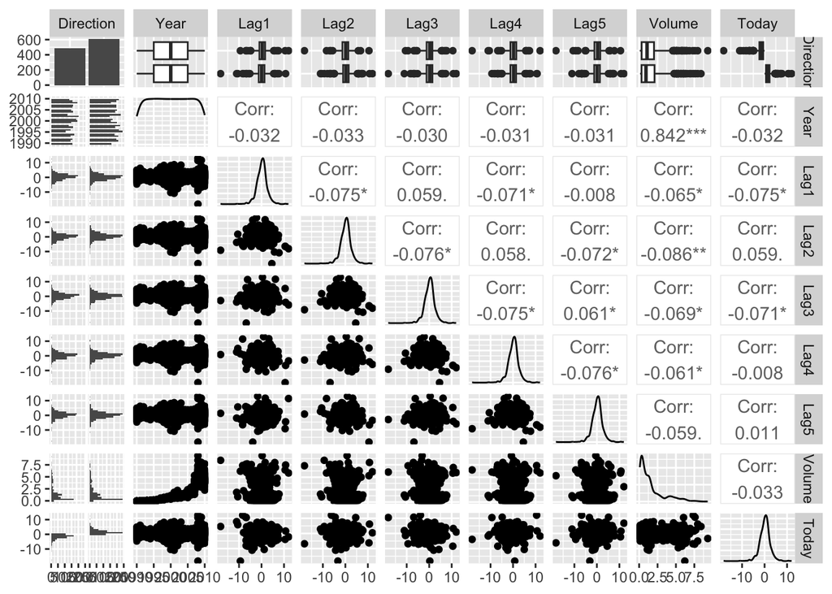

```r
GGally::ggpairs(Weekly[,c(9, 1:8)])
```

```r
glmout <- glm(Direction ~ Volume + Lag1 + Lag2 + Lag3 + Lag4 + Lag5,
              family="binomial", data = Weekly)
summary(glmout)
```

```
Call:
glm(formula = Direction ~ Volume + Lag1 + Lag2 + Lag3 + Lag4 +
    Lag5, family = "binomial", data = Weekly)

Deviance Residuals:
    Min       1Q   Median       3Q      Max
-1.6949  -1.2565   0.9913   1.0849   1.4579

Coefficients:
            Estimate Std. Error z value Pr(>|z|)
(Intercept)  0.26686    0.08593   3.106   0.0019 **
Volume      -0.02274    0.03690  -0.616   0.5377
Lag1        -0.04127    0.02641  -1.563   0.1181
Lag2         0.05844    0.02686   2.175   0.0296 *
Lag3        -0.01606    0.02666  -0.602   0.5469
Lag4        -0.02779    0.02646  -1.050   0.2937
Lag5        -0.01447    0.02638  -0.549   0.5833
---
Signif. codes:  0 '***' 0.001 '**' 0.01 '*' 0.05 '.' 0.1 ' ' 1

(Dispersion parameter for binomial family taken to be 1)

    Null deviance: 1496.2  on 1088  degrees of freedom
Residual deviance: 1486.4  on 1082  degrees of freedom
AIC: 1500.4

Number of Fisher Scoring iterations: 4
```

```r
# Note only Lag2 appears significant
# All the correlations among the lags are low.
```

2. Split the data set into training and testing data and use the KNN method with $K = 9$ to predict `Direction` as the response based on the five lag variables plus `Volume` as predictors. Use split percentage of 70%. Why or why not is this a good split percentage? Use seed 1235.

```r
library(class)
set.seed(1235)
nrow(Weekly)
```

```
[1] 1089
```

```r
training_pct <- .70
# with over 1000 observations this leaves at least 300 for testing
nrow(Weekly)*training_pct
```

```
[1] 762.3
```

```r
Z = sample(nrow(Weekly), floor(training_pct*nrow(Weekly)))

Xtrain = Weekly[Z,2:7] # Our training set X
Ytrain = Weekly$Direction[Z]  # Our training set y
Xtest = Weekly[-Z,2:7]
Yhat <- knn(Xtrain, Xtest, Ytrain, k = 9)
Ytest <- Weekly$Direction[-Z]
```

3. Compute the confusion matrix, showing cross-tabulation of the actual and predicted responses.

```r
conf_matrix <- table(Ytest, Yhat)
conf_matrix
```

```
      Yhat
Ytest  Down  Up
  Down   51  94
  Up     67 115
```

4. Compute the classification rate, which is the overall fraction of **correct** predictions.

```r
class_rate = (table(Ytest, Yhat)[1, 1] + table(Ytest, Yhat)[2, 2])/((1 - training_pct)*nrow(Weekly))
class_rate
```

```
[1] 0.5081114
```

5. Tuning. Try different values of the tuning parameter $K$ and select the optimal one; the one which minimizes the prediction *error* rate. Report the optimal $K$ and the associated **error rate**.

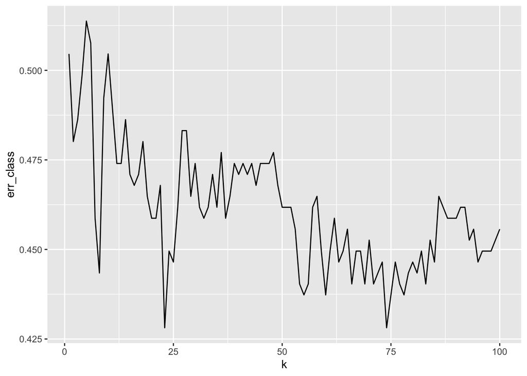

```r
# Initialize data
err_class <- rep(1:100)
tpr <- rep(1:100)
fpr <- rep(1:100)

# run the loop
for (k in 1:100){
  Yhat <- knn(Xtrain, Xtest, Ytrain, k = k)
  err_class[k] <- mean(Yhat != Ytest) # The prediction is not correct
  tpr[k] <- sum(Yhat == 1 & Ytest == 1) / sum(Ytest == 1) # TP/P
  fpr[k] <- sum(Yhat == 1 & Ytest == 0) / sum(Ytest == 0) # FP/N
}

ggplot(tibble(err_class, k = 1:100), aes(x = k, y = err_class)) +
  geom_line()
```

```r
which.min(err_class) # gives the k
```

```
[1] 23
```

```r
err_class[which.min(err_class)] # Probability of a Mis-classification
```

```
[1] 0.4281346
```

# 4 Dimensionality (STAT-627 only)

Pages 199-201, chap. 24

When the number of features $p$ is large, there tends to be a deterioration in the performance of KNN and other local approaches that perform prediction using only observations that are *near* the test observation for which a prediction must be made. This phenomenon is known as the *curse of dimensionality*, and it ties into the fact that non-parametric approaches often perform poorly when $p$ is large. We will now investigate this curse.

1. Suppose we have a set of observations, each with measurements on $p$ = 1 feature, $X$. We assume that $X$ is uniformly (evenly) distributed on $[0, 1]$. Associated with each observation is a response value.

We wish to predict a test observation’s response using only observations that are **within 10%** of the range of $X$ closest to that test observation. For instance, to predict the response for a test observation with $X = 0.6$, we will use observations in the range $[0.55, 0.65]$.

- On average, what fraction of the available observations will we use to make the prediction?

On the average, the fraction of observations in [0.55, 0.65] is the probability of any $X$ to be within this interval.

1. From the Uniform(0,1) distribution, $P( 0.55 ≤ X ≤ 0.65 ) = 0.10$.

Thus, 10% of all the data belong to the neighborhood of the given point.

2. Now suppose we have a set of observations, each with measurements on $p = 2$ features, $X_1$ and $X_2$. We assume that $(X_1, X_2)$ are uniformly distributed on $[0, 1] × [0, 1]$ and are independent. We wish to predict a test observation’s response using only observations that are within 10% of the range of $X_1$ **and** within 10% of the range of $X_2$ closest to that test observation. For instance, to predict the response for a test observation with $X_1 = 0.6 \text{ and } X_2 = 0.35$, we will use observations in the range $[0.55, 0.65]$ for $X_1$ and in the range $[0.3, 0.4]$ for $X_2$.
- On average, what fraction of the available observations will we use to make the prediction?

2. The fraction is $P( 0.55 ≤ X1 ≤ 0.65 \text{ and } 0.3 ≤ X2 ≤ 0.4 ) = (0.1)(0.1) = 0.01.$ since they are independent.

Only 1% of the data form the neighborhood now.

3. Now suppose we have a set of observations on $p = 100$ features. Again the observations are uniformly distributed on each feature, and each feature ranges in value from 0 to 1. We wish to predict a test observation’s response using observations within the 10% of each feature’s range that is closest to that test observation.
- What fraction of the available observations will we use to make the prediction?
3. Similarly, the fraction is now $(0.1)(0.1)…(0.1) = (0.1)^{100}$.

We would have to have many many observations to get even one nearest neighbor.

4. Using your answers to parts (a)-(c), argue that a drawback of KNN when $p$ is large is there are very few training observations “near” any given test observation.
4. For large $p$, a very tiny fraction of data is available for neighborhood-based classification. With a very high probability, we’ll have no data at all within 10% range in each $X$ variable (in each feature). In such cases, KNN will not be possible.
5. We wish to make a prediction for a test observation by creating a $p$-dimensional hyper-cube centered around the test observation that contains, on average, 10% of the training observations (for our variables that are i.i.d. Uniform (0, 1)).

For $p$ = 1, 2, and 100, What is the length of each side of the hyper-cube? Comment on your answer.

Note: A hyper-cube is a generalization of a cube to an arbitrary number of dimensions. When $p$ = 1, a hyper-cube is simply a line segment, when $p = 2$ it is a square, and when $p = 100$ it is a 100-dimensional cube.

5. The volume of a hyper-cube is $s^p$, where $s$ is the side of a hyper-cube and $p$ is the dimension.

Thus we want to find $s$ for a hyper-cube of dimension $p$ where the volume = .1 or

$$s^p=0.1 \tag{1}$$

Taking the $p^\text{th}$ root of both sides of Equation 1 gives us $s=(0.1)^{1/p}$.

This number gets close to 1 when $p$ gets large as $(1/p) \rightarrow 0$ with the limit as $p \rightarrow \infty$ of $0.1^0 = 1$.

For $p=1$, the side of the hyper-cube with 10% of the data is $s=0.1$.

For $p=2$, the side of the hyper-cube with 10% of the data is $s=0.316$.

For $p=100$, the side of the hyper-cube with 10% of the data is $s=0.977$.

It might sound strange that to get 10% of the data, we have to make a cube that is almost as big as the hyper-cube. This is because the points are so spread out in 100 dimensions it is tough to find neighbors.

Thus to get any number of neighbors, you need an extremely high number of observations and all the points will still be far away. This can lead to increasing the K until you are using nearly 100% of the data forming the neighborhood of each point. When you do that, the KNN method will make the same prediction for all points regardless of their location inside the hyper-cube. The method will be extremely inflexible, too inflexible to be of any use.

# 5 AI Frameworks for Transparency

Listen to the Cognilytica Podcast [AI System Transparency](https://www.cognilytica.com/2022/09/14/ai-today-podcast-ethical-responsible-ai-series-ai-system-transparency/) (skip to start about 5:55) and in a few short sentences discuss how adopting some sort of framework for AI System Transparency might be useful for the reproducibility of your future Machine Learning projects. From your perspective, what is the primary ethical benefit of using such a framework and what are the most important elements of your transparency framework?

Any cogent and relevant response.